# ADP4

## 5.2 hierarchical k-means

**optimal cluster k**

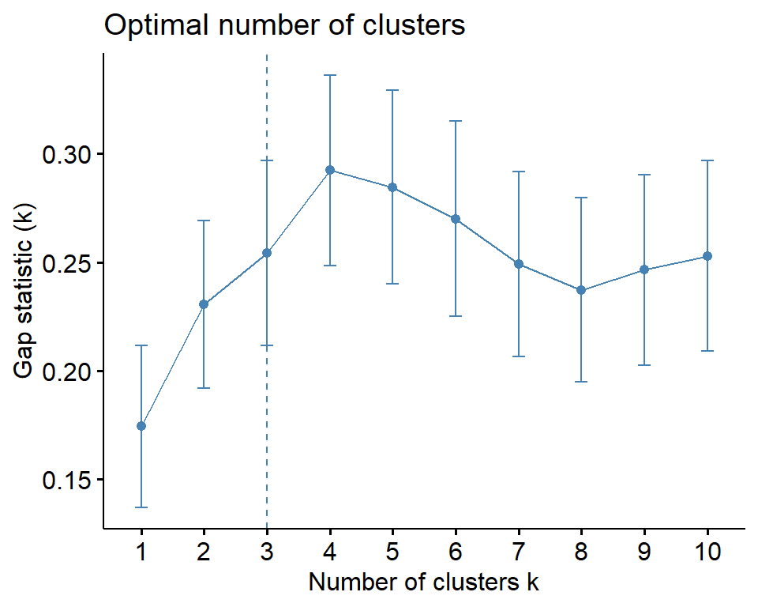

```r
set.seed(123)
fviz_nbclust(df_6, hkmeans, method = "gap_stat")
```

**Compute hk-means**

```r
set.seed(123)
res.hk <- hkmeans(df_6, 3)
```

**Visualization**

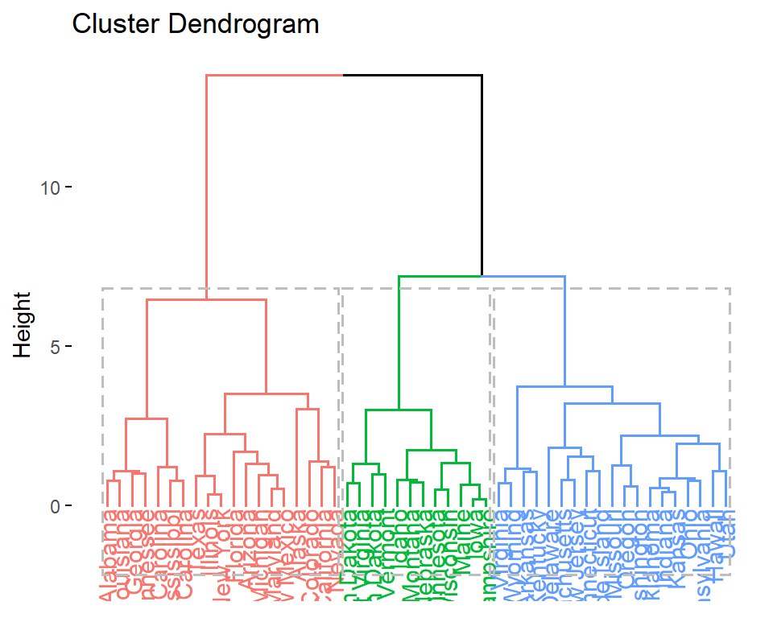

```r
fviz_dend(res.hk, rect = T) # rect = T : 정사각형 점선 추가
```

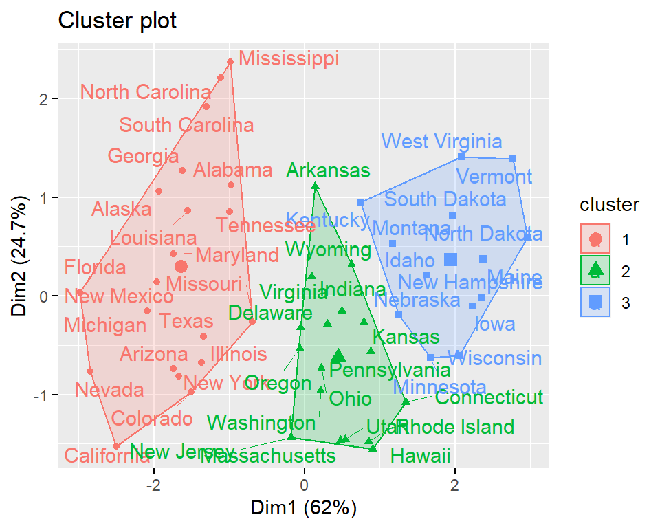

```r
fviz_cluster(res.hk, repel = TRUE) # repel = T : label 중첩 방지
```

## 5.3 PCA

- factorextra 패키지가 가장 효율적
- recipe를 이용할 수도 있지만 시각화 코드가 긴 단점이 있음
- 시각화까지 전부 해야되면 **factorextra**, 전처리만 해도 되면 **recipes** 쓰면 됨

**Example**

```r
df_5 <- decathlon2[1:23, 1:10]
df_5
```

```
##             X100m Long.jump Shot.put High.jump X400m X110m.hurdle Discus
## SEBRLE      11.04      7.58    14.83      2.07 49.81        14.69  43.75
## CLAY        10.76      7.40    14.26      1.86 49.37        14.05  50.72
## BERNARD     11.02      7.23    14.25      1.92 48.93        14.99  40.87
## YURKOV      11.34      7.09    15.19      2.10 50.42        15.31  46.26
## ZSIVOCZKY   11.13      7.30    13.48      2.01 48.62        14.17  45.67
## McMULLEN    10.83      7.31    13.76      2.13 49.91        14.38  44.41
## MARTINEAU   11.64      6.81    14.57      1.95 50.14        14.93  47.60
## HERNU       11.37      7.56    14.41      1.86 51.10        15.06  44.99
## BARRAS      11.33      6.97    14.09      1.95 49.48        14.48  42.10
## NOOL        11.33      7.27    12.68      1.98 49.20        15.29  37.92
## BOURGUIGNON 11.36      6.80    13.46      1.86 51.16        15.67  40.49
## Sebrle      10.85      7.84    16.36      2.12 48.36        14.05  48.72
## Clay        10.44      7.96    15.23      2.06 49.19        14.13  50.11
## Karpov      10.50      7.81    15.93      2.09 46.81        13.97  51.65
## Macey       10.89      7.47    15.73      2.15 48.97        14.56  48.34
## Warners     10.62      7.74    14.48      1.97 47.97        14.01  43.73
## Zsivoczky   10.91      7.14    15.31      2.12 49.40        14.95  45.62
## Hernu       10.97      7.19    14.65      2.03 48.73        14.25  44.72
## Bernard     10.69      7.48    14.80      2.12 49.13        14.17  44.75
## Schwarzl    10.98      7.49    14.01      1.94 49.76        14.25  42.43
## Pogorelov   10.95      7.31    15.10      2.06 50.79        14.21  44.60
## Schoenbeck  10.90      7.30    14.77      1.88 50.30        14.34  44.41
## Barras      11.14      6.99    14.91      1.94 49.41        14.37  44.83
##             Pole.vault Javeline X1500m
## SEBRLE            5.02    63.19 291.70
## CLAY              4.92    60.15 301.50
## BERNARD           5.32    62.77 280.10
## YURKOV            4.72    63.44 276.40
## ZSIVOCZKY         4.42    55.37 268.00
## McMULLEN          4.42    56.37 285.10
## MARTINEAU         4.92    52.33 262.10
## HERNU             4.82    57.19 285.10
## BARRAS            4.72    55.40 282.00
## NOOL              4.62    57.44 266.60
## BOURGUIGNON       5.02    54.68 291.70
## Sebrle            5.00    70.52 280.01
## Clay              4.90    69.71 282.00
## Karpov            4.60    55.54 278.11
## Macey             4.40    58.46 265.42
## Warners           4.90    55.39 278.05
## Zsivoczky         4.70    63.45 269.54
## Hernu             4.80    57.76 264.35
## Bernard           4.40    55.27 276.31
## Schwarzl          5.10    56.32 273.56
## Pogorelov         5.00    53.45 287.63
## Schoenbeck        5.00    60.89 278.82
## Barras            4.60    64.55 267.09
```

- 그냥 prcomp 써도 상관없음
- FactoMineR 패키지의 PCA는 scaling이 default임
- graph = T로 설정했을 때 시각화까지 수행해줌

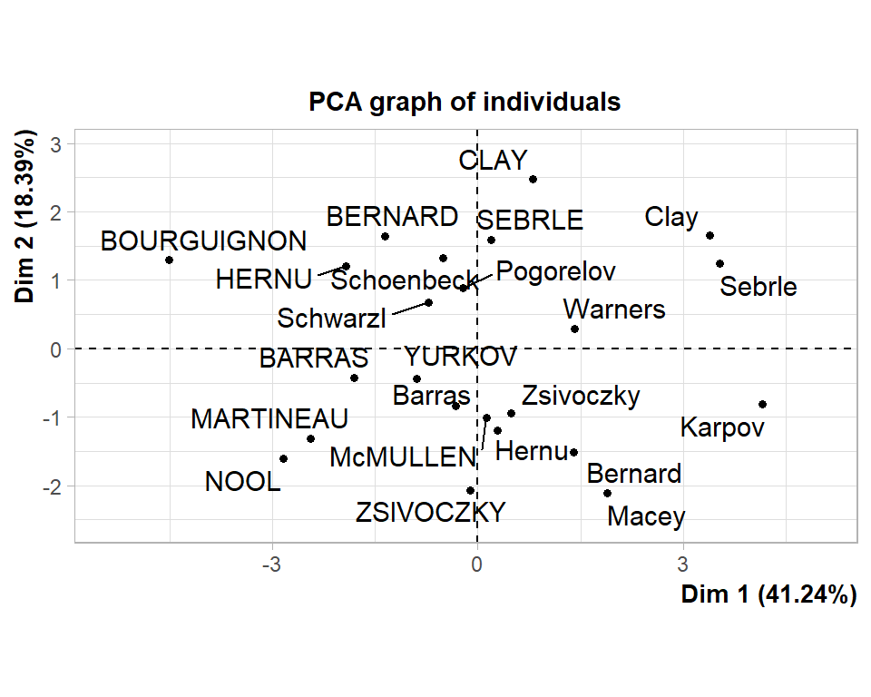

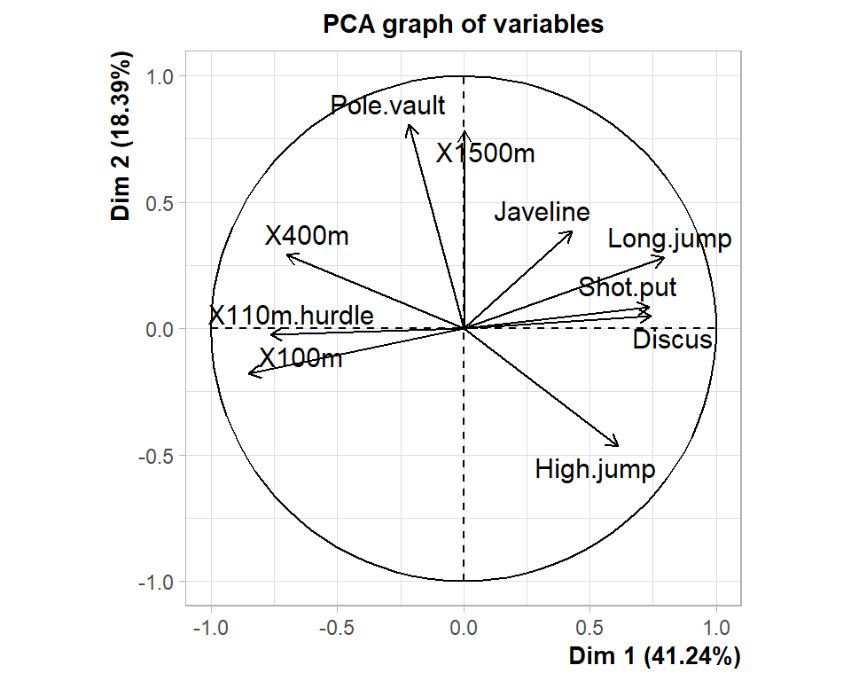

```
## **Results for the Principal Component Analysis (PCA)**
## The analysis was performed on 23 individuals, described by 10 variables
## *The results are available in the following objects:
##
##    name               description
## 1  "$eig"             "eigenvalues"
## 2  "$var"             "results for the variables"
## 3  "$var$coord"       "coord. for the variables"
## 4  "$var$cor"         "correlations variables - dimensions"
## 5  "$var$cos2"        "cos2 for the variables"
## 6  "$var$contrib"     "contributions of the variables"
## 7  "$ind"             "results for the individuals"
## 8  "$ind$coord"       "coord. for the individuals"
## 9  "$ind$cos2"        "cos2 for the individuals"
## 10 "$ind$contrib"     "contributions of the individuals"
## 11 "$call"            "summary statistics"
## 12 "$call$centre"     "mean of the variables"
## 13 "$call$ecart.type" "standard error of the variables"
## 14 "$call$row.w"      "weights for the individuals"
## 15 "$call$col.w"      "weights for the variables"
```

```r
library(FactoMineR)
PCA(df_5, graph = T) # scale.unit = T default
```

**eigenvalue/variance 추출**

```r
res.pca <- PCA(df_5, graph = F)
get_eig(res.pca)
```

```
##        eigenvalue variance.percent cumulative.variance.percent
## Dim.1   4.1242133        41.242133                    41.24213
## Dim.2   1.8385309        18.385309                    59.62744
## Dim.3   1.2391403        12.391403                    72.01885
## Dim.4   0.8194402         8.194402                    80.21325
## Dim.5   0.7015528         7.015528                    87.22878
## Dim.6   0.4228828         4.228828                    91.45760
## Dim.7   0.3025817         3.025817                    94.48342
## Dim.8   0.2744700         2.744700                    97.22812
## Dim.9   0.1552169         1.552169                    98.78029
## Dim.10  0.1219710         1.219710                   100.00000
```

**screeplot**

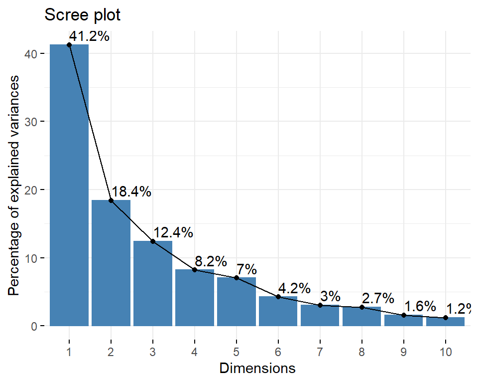

```r
fviz_screeplot(res.pca, addlabels = T) # add_labels = T : 퍼센트 표시
```

**Bi plot**

```r
res.pca$var$coord %>% head()
```

```
##                   Dim.1       Dim.2      Dim.3       Dim.4      Dim.5
## X100m        -0.8506257 -0.17939806  0.3015564  0.03357320 -0.1944440
## Long.jump     0.7941806  0.28085695 -0.1905465 -0.11538956  0.2331567
## Shot.put      0.7339127  0.08540412  0.5175978  0.12846837 -0.2488129
## High.jump     0.6100840 -0.46521415  0.3300852  0.14455012  0.4027002
## X400m        -0.7016034  0.29017826  0.2835329  0.43082552  0.1039085
## X110m.hurdle -0.7641252 -0.02474081  0.4488873 -0.01689589  0.2242200
```

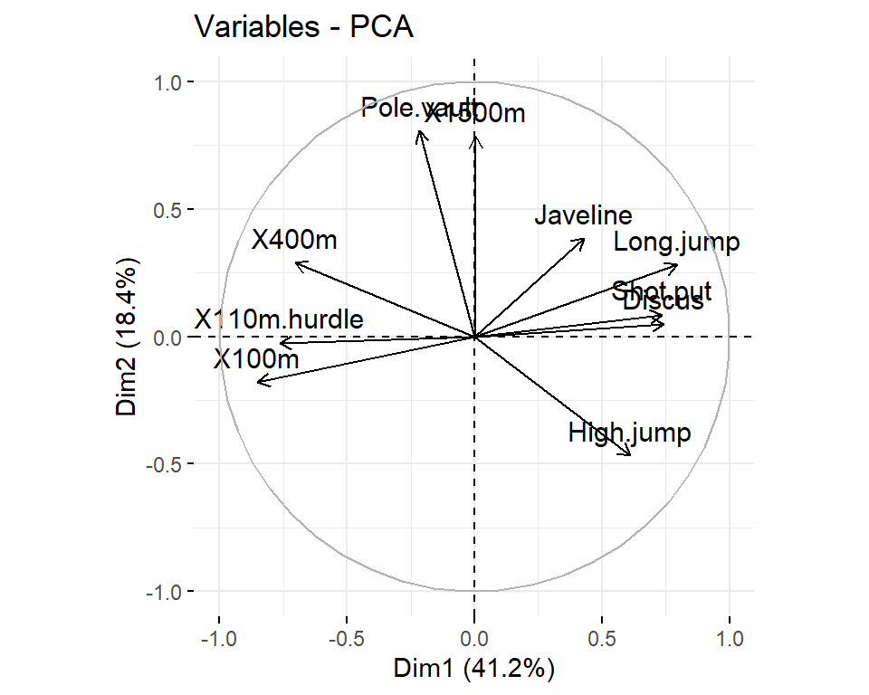

```r
fviz_pca_var(res.pca)
```

- 주성분 별로 계수의 효과를 파악하기 어렵기 때문에 plot을 그려서 확인
- 화살표가 찍히는 꼭지점의 좌표는 각 주성분에서 특정 변수의 가중치 값이 됨
- 예를 들어 Pole.vault의 경우 PC1의 가중치는 -0.21, PC2의 가중치는 0.8이므로 해당 좌표(-0.21, 0.8)에 점이 찍힘
- 즉 주성분 축에 평행할수록 해당 변수는 주성분에 크게 기여했다고 볼 수 있음
- 같은 각도로 뻗어나가는 경우 서로 비슷한 변수라고 볼 수 있음

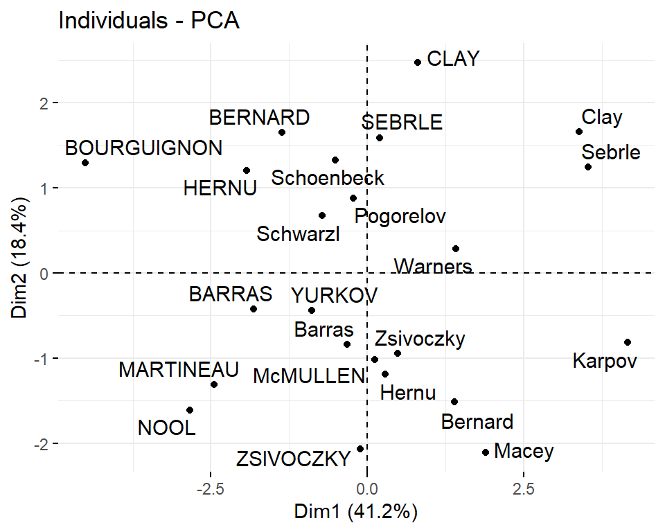

```r
fviz_pca_ind(res.pca, repel = T)
```

```r
res.pca$ind$coord %>% head()
```

```
##                Dim.1      Dim.2      Dim.3       Dim.4       Dim.5
## SEBRLE     0.1955047  1.5890567  0.6424912  0.08389652  1.16829387
## CLAY       0.8078795  2.4748137 -1.3873827  1.29838232 -0.82498206
## BERNARD   -1.3591340  1.6480950  0.2005584 -1.96409420  0.08419345
## YURKOV    -0.8889532 -0.4426067  2.5295843  0.71290837  0.40782264
## ZSIVOCZKY -0.1081216 -2.0688377 -1.3342591 -0.10152796 -0.20145217
## McMULLEN   0.1212195 -1.0139102 -0.8625170  1.34164291  1.62151286
```

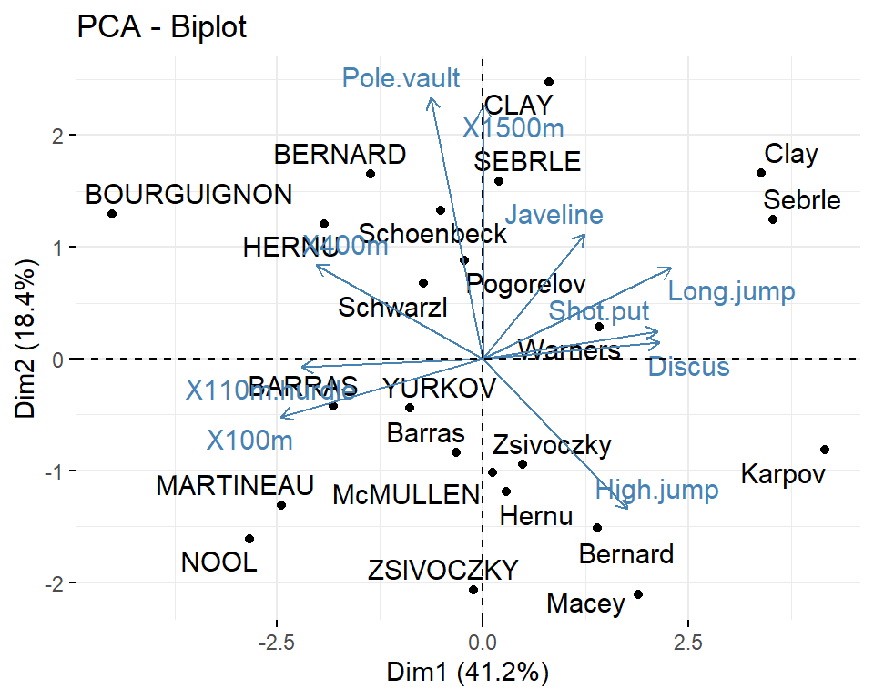

```r
fviz_pca_biplot(res.pca, repel = TRUE)
```

## 5.4 hierarchical clustering

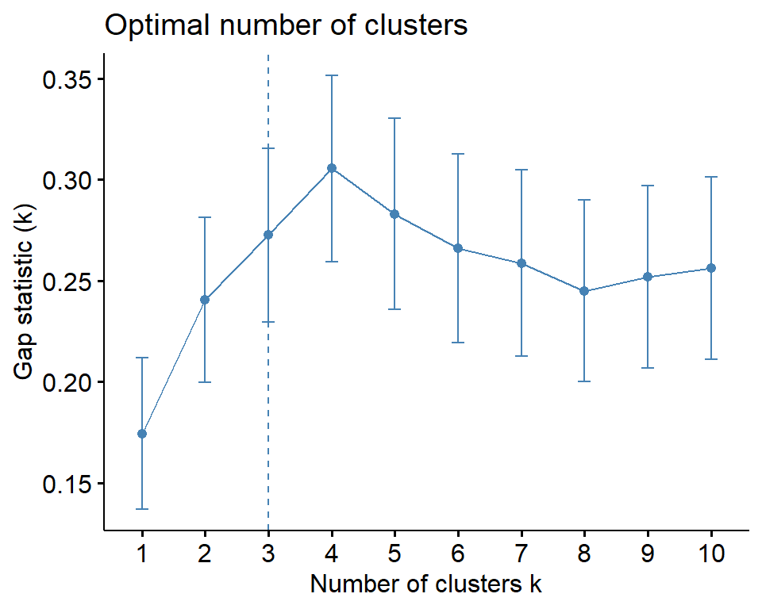

```r
set.seed(123)
fviz_nbclust(df_6, hcut, method = "gap_stat")
```

```r
set.seed(123)
res <- hcut(USArrests, k = 3, stand = T)
res
```

```
##
## Call:
## stats::hclust(d = x, method = hc_method)
##
## Cluster method   : ward.D2
## Distance         : euclidean
## Number of objects: 50
```

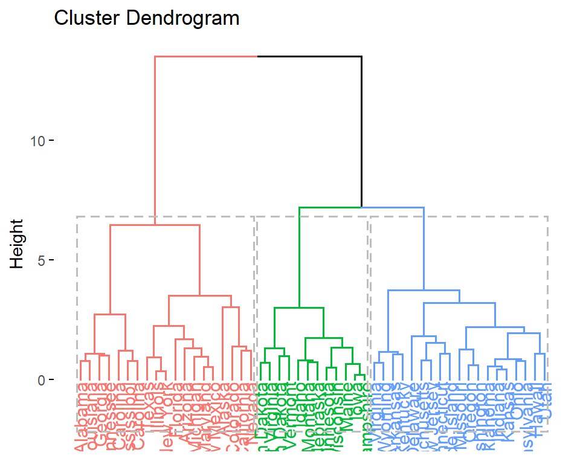

```r
fviz_dend(res, rect = TRUE)
```

## 5.5 SOM

**Data description**

xyz 회사의 광고 데이터

- ad_id : an unique ID of each ad
- xyz_campaign_id : an ID associated with each ad campaign of XYZ company
- fb_campaign_id : an ID associated with how Facebook tracks each campaign
- age : age of the person to whom the ad is shown
- gender : gender of the person to whon thw ad si shown
- interest : a code specifying the category to which the person’s interest belongs (interests are as mentioned in the person’s Facebook public profile)
- Impressions : number of time the ad is shown
- Clicks : number od click on for the ad
- Spent : amount paid from xyz company to Facebook to shown the ad
- Total_Conversion : total number of people who enquired about the product after seeing the ad
- approved_Conversion : total number of people who bougth the product after seeing the ad

https://rpubs.com/AlgoritmaAcademy/som

```r
# kohonen   3.0.10
# devtools::install_version("kohonen", version = "3.0.10")
library(kohonen)

dat_7 <- fread("data/KAG.csv")

dat_7 %>% glimpse()
```

```
## Rows: 1,143
## Columns: 11
## $ ad_id               <int> 708746, 708749, 708771, 708815, 708818, 708820, 70~
## $ xyz_campaign_id     <int> 916, 916, 916, 916, 916, 916, 916, 916, 916, 916, ~
## $ fb_campaign_id      <int> 103916, 103917, 103920, 103928, 103928, 103929, 10~
## $ age                 <chr> "30-34", "30-34", "30-34", "30-34", "30-34", "30-3~
## $ gender              <chr> "M", "M", "M", "M", "M", "M", "M", "M", "M", "M", ~
## $ interest            <int> 15, 16, 20, 28, 28, 29, 15, 16, 27, 28, 31, 7, 16,~
## $ Impressions         <int> 7350, 17861, 693, 4259, 4133, 1915, 15615, 10951, ~
## $ Clicks              <int> 1, 2, 0, 1, 1, 0, 3, 1, 1, 3, 0, 0, 0, 0, 7, 0, 1,~
## $ Spent               <dbl> 1.43, 1.82, 0.00, 1.25, 1.29, 0.00, 4.77, 1.27, 1.~
## $ Total_Conversion    <int> 2, 2, 1, 1, 1, 1, 1, 1, 1, 1, 1, 1, 1, 1, 1, 1, 1,~
## $ Approved_Conversion <int> 1, 0, 0, 0, 1, 1, 0, 1, 0, 0, 0, 0, 0, 0, 1, 1, 0,~
```

```r
dat_7 <- dat_7 %>%
  mutate(ad_id = as.factor(ad_id),
         xyz_campaign_id = as.factor(xyz_campaign_id),
         fb_campaign_id = as.factor(fb_campaign_id))
```

**dummy coding**

- 범주형 변수에 대해 dummy coding 필요

```r
ads.s <- dat_7 %>%
  mutate(genderM = ifelse(gender == "M", 1, 0),
         age2 = ifelse(age == "35-39", 1, 0),
         age3 = ifelse(age == "40-44", 1, 0),
         age4 = ifelse(age == "45-49", 1, 0)) %>%
  select(-c(1,3:5))
```

```r
ads.train <- as.matrix(scale(ads.s[,-1]))
ads.train %>% head()
```

```
##        interest Impressions     Clicks      Spent Total_Conversion
## [1,] -0.6591837  -0.5735416 -0.5693235 -0.5745204       -0.1908387
## [2,] -0.6220808  -0.5399346 -0.5517465 -0.5700329       -0.1908387
## [3,] -0.4736696  -0.5948262 -0.5869005 -0.5909745       -0.4138741
## [4,] -0.1768470  -0.5834245 -0.5693235 -0.5765915       -0.4138741
## [5,] -0.1768470  -0.5838274 -0.5693235 -0.5761313       -0.4138741
## [6,] -0.1397442  -0.5909191 -0.5869005 -0.5909745       -0.4138741
##      Approved_Conversion   genderM       age2       age3       age4
## [1,]          0.03222233 0.9643282 -0.5261678 -0.4742188 -0.5410454
## [2,]         -0.54324835 0.9643282 -0.5261678 -0.4742188 -0.5410454
## [3,]         -0.54324835 0.9643282 -0.5261678 -0.4742188 -0.5410454
## [4,]         -0.54324835 0.9643282 -0.5261678 -0.4742188 -0.5410454
## [5,]          0.03222233 0.9643282 -0.5261678 -0.4742188 -0.5410454
## [6,]          0.03222233 0.9643282 -0.5261678 -0.4742188 -0.5410454
```

```r
# make a SOM grid
set.seed(100)
ads.grid <- somgrid(xdim = 10, ydim = 10, topo = "hexagonal")

# make a SOM model
set.seed(100)
ads.model <- som(ads.train, ads.grid,
                  rlen = 500,
                  radius = 2.5, # 뉴런의 반경
                  keep.data = TRUE, # return original data
                  dist.fcts = "euclidean")
```

```r
library(factoextra)
ads.model$codes[[1]] %>% dim()
```

```
## [1] 100  10
```

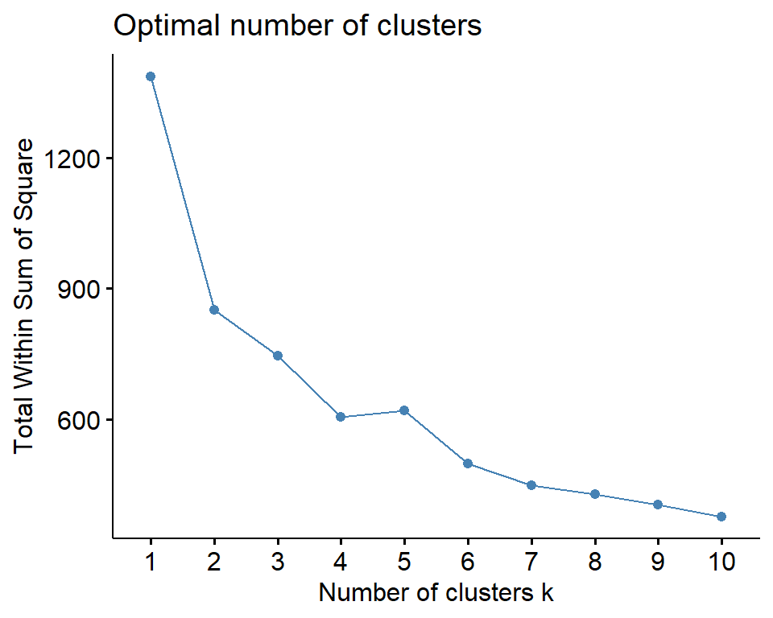

```r
set.seed(100)
fviz_nbclust(ads.model$codes[[1]], kmeans, method = "wss")
```

```r
set.seed(100)
clust <- kmeans(ads.model$codes[[1]], 6)
```

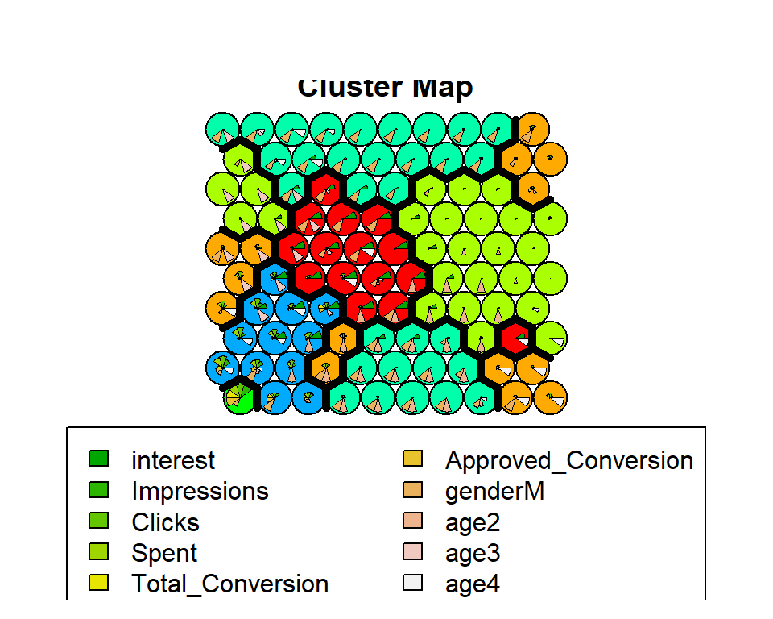

```r
# 각 class가 뉴런의 학습에 기여한 기여율
plot(ads.model, type = "codes", bgcol = rainbow(9)[clust$cluster], main = "Cluster Map")
add.cluster.boundaries(ads.model, clust$cluster)
```

```r
ads.cluster <- data.frame(ads.s, cluster = clust$cluster[ads.model$unit.classif])
tail(ads.cluster, 5)
```

```
##      xyz_campaign_id interest Impressions Clicks  Spent Total_Conversion
## 1139            1178      109     1129773    252 358.19               13
## 1140            1178      110      637549    120 173.88                3
## 1141            1178      111      151531     28  40.29                2
## 1142            1178      113      790253    135 198.71                8
## 1143            1178      114      513161    114 165.61                5
##      Approved_Conversion genderM age2 age3 age4 cluster
## 1139                   2       0    0    0    1       6
## 1140                   0       0    0    0    1       1
## 1141                   0       0    0    0    1       1
## 1142                   2       0    0    0    1       1
## 1143                   2       0    0    0    1       1
```

# 6 Clustering and modeling tutorial

## 6.1 수치형 변수만 선택

```r
df_k <- ads.s %>%
  select(interest, Impressions, Clicks, Spent, Total_Conversion)

df_k <- scale(df_k)
```

## 6.2 optimal cluster

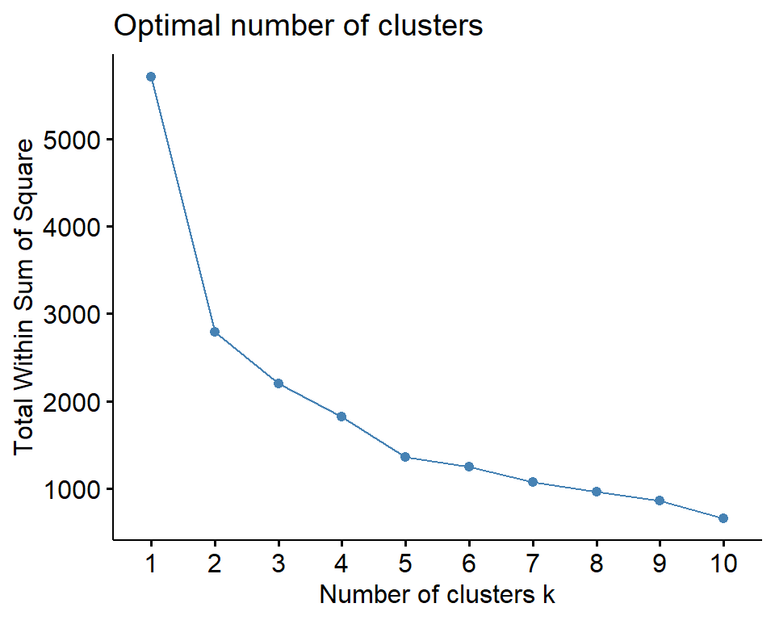

```r
set.seed(123)
fviz_nbclust(df_k, kmeans, method = "wss")
```

## 6.3 kmeans

```r
set.seed(123)
km.res <- kmeans(df_k, 4, nstart = 25)
km.res$cluster %>% head()
```

```
## [1] 2 2 2 2 2 2
```

```r
clust = data.frame(clust = km.res$cluster)

df_k %>% dim()
```

```
## [1] 1143    5
```

```r
clust %>% dim()
```

```
## [1] 1143    1
```

## 6.4 데이터 병합

- bind_cols는 error가 날 수도 있으므로 cbind 사용 추천

```r
df_k <- cbind(df_k, clust)

newdat <- ads.s %>%
  select(-c(interest, Impressions, Clicks, Spent, Total_Conversion)) %>%
  cbind(df_k)

newdat %>% head()
```

```
##    xyz_campaign_id Approved_Conversion genderM age2 age3 age4   interest
## 1:             916                   1       1    0    0    0 -0.6591837
## 2:             916                   0       1    0    0    0 -0.6220808
## 3:             916                   0       1    0    0    0 -0.4736696
## 4:             916                   0       1    0    0    0 -0.1768470
## 5:             916                   1       1    0    0    0 -0.1768470
## 6:             916                   1       1    0    0    0 -0.1397442
##    Impressions     Clicks      Spent Total_Conversion clust
## 1:  -0.5735416 -0.5693235 -0.5745204       -0.1908387     2
## 2:  -0.5399346 -0.5517465 -0.5700329       -0.1908387     2
## 3:  -0.5948262 -0.5869005 -0.5909745       -0.4138741     2
## 4:  -0.5834245 -0.5693235 -0.5765915       -0.4138741     2
## 5:  -0.5838274 -0.5693235 -0.5761313       -0.4138741     2
## 6:  -0.5909191 -0.5869005 -0.5909745       -0.4138741     2
```

## 6.5 Modeling

```r
library(caret)
library(rsample)

newdat$xyz_campaign_id <- factor(newdat$xyz_campaign_id, labels = c("A", "B", "C"))

splits <- initial_split(newdat, prop = 0.7, strata = xyz_campaign_id)
train <- training(splits)
test <- testing(splits)

set.seed(123)
control <- trainControl(method='cv',
                        number=5,
                        classProbs = T,
                        summaryFunction = multiClassSummary,
                        savePredictions = T
                        )
tunegrid <- expand.grid(mtry = c(1:5))

rf_gridsearch <- train(xyz_campaign_id ~ .,
                       data = train,
                       method = 'rf',
                       trControl = control,
                       tuneGrid = tunegrid,
                       metric = "logLoss")

rf_gridsearch
```

```
## Random Forest
##
## 799 samples
##  11 predictor
##   3 classes: 'A', 'B', 'C'
##
## No pre-processing
## Resampling: Cross-Validated (5 fold)
## Summary of sample sizes: 639, 640, 639, 639, 639
## Resampling results across tuning parameters:
##
##   mtry  logLoss    AUC        prAUC      Accuracy   Kappa      Mean_F1
##   1     0.5208027  0.8744036  0.6192190  0.8710613  0.7498075        NaN
##   2     0.3355075  0.8988662  0.6128737  0.8936242  0.7935224        NaN
##   3     0.3087578  0.9097478  0.5991057  0.8973664  0.8008750  0.7054367
##   4     0.3027806  0.9105281  0.5878476  0.8986242  0.8031544  0.7022166
##   5     0.3030347  0.9097650  0.5733420  0.8986164  0.8034088  0.7183616
##   Mean_Sensitivity  Mean_Specificity  Mean_Pos_Pred_Value  Mean_Neg_Pred_Value
##   0.6057522         0.9202118               NaN            0.9271071
##   0.6212097         0.9346826               NaN            0.9423885
##   0.6335766         0.9370609         0.7800866            0.9446403
##   0.6338223         0.9378424         0.7325977            0.9458225
##   0.6340817         0.9380562         0.6866353            0.9456938
##   Mean_Precision  Mean_Recall  Mean_Detection_Rate  Mean_Balanced_Accuracy
##         NaN       0.6057522    0.2903538            0.7629820
##         NaN       0.6212097    0.2978747            0.7779462
##   0.7800866       0.6335766    0.2991221            0.7853187
##   0.7325977       0.6338223    0.2995414            0.7858323
##   0.6866353       0.6340817    0.2995388            0.7860690
##
## logLoss was used to select the optimal model using the smallest value.
## The final value used for the model was mtry = 4.
```

```r
pred <- predict(rf_gridsearch, newdata = test, type = "raw")

cmatrix <- caret::confusionMatrix(pred, test$xyz_campaign_id)
cmatrix
```

```
## Confusion Matrix and Statistics
##
##           Reference
## Prediction   A   B   C
##          A   0   2   0
##          B  21 125  10
##          C   0   9 177
##
## Overall Statistics
##
##                Accuracy : 0.8779
##                  95% CI : (0.8386, 0.9106)
##     No Information Rate : 0.5436
##     P-Value [Acc > NIR] : < 2.2e-16
##
##                   Kappa : 0.7681
##
##  Mcnemar's Test P-Value : NA
##
## Statistics by Class:
##
##                      Class: A Class: B Class: C
## Sensitivity          0.000000   0.9191   0.9465
## Specificity          0.993808   0.8510   0.9427
## Pos Pred Value       0.000000   0.8013   0.9516
## Neg Pred Value       0.938596   0.9415   0.9367
## Prevalence           0.061047   0.3953   0.5436
## Detection Rate       0.000000   0.3634   0.5145
## Detection Prevalence 0.005814   0.4535   0.5407
## Balanced Accuracy    0.496904   0.8850   0.9446
```

# 7 PCA and modeling tutorial

https://www.kaggle.com/uciml/breast-cancer-wisconsin-data

UCI machine learning 데이터가 시험에 나오는 경우가 많은 것 같아서 kaggle tutorial 중에 pca 후 모델링 관련 괜찮은 데이터를 골랐습니다.

## 7.1 데이터 불러오기

```r
cancer <- fread("data/cancer.csv", fill = T) # fill = T : 행길이가 다를 경우 강제로 채워줌

cancer <- cancer %>%
  select(-c(id, V33)) %>%
  janitor::clean_names()

cancer %>% glimpse()
```

```
## Rows: 569
## Columns: 31
## $ diagnosis               <chr> "M", "M", "M", "M", "M", "M", "M", "M", "M", "~
## $ radius_mean             <dbl> 17.990, 20.570, 19.690, 11.420, 20.290, 12.450~
## $ texture_mean            <dbl> 10.38, 17.77, 21.25, 20.38, 14.34, 15.70, 19.9~
## $ perimeter_mean          <dbl> 122.80, 132.90, 130.00, 77.58, 135.10, 82.57, ~
## $ area_mean               <dbl> 1001.0, 1326.0, 1203.0, 386.1, 1297.0, 477.1, ~
## $ smoothness_mean         <dbl> 0.11840, 0.08474, 0.10960, 0.14250, 0.10030, 0~
## $ compactness_mean        <dbl> 0.27760, 0.07864, 0.15990, 0.28390, 0.13280, 0~
## $ concavity_mean          <dbl> 0.30010, 0.08690, 0.19740, 0.24140, 0.19800, 0~
## $ concave_points_mean     <dbl> 0.14710, 0.07017, 0.12790, 0.10520, 0.10430, 0~
## $ symmetry_mean           <dbl> 0.2419, 0.1812, 0.2069, 0.2597, 0.1809, 0.2087~
## $ fractal_dimension_mean  <dbl> 0.07871, 0.05667, 0.05999, 0.09744, 0.05883, 0~
## $ radius_se               <dbl> 1.0950, 0.5435, 0.7456, 0.4956, 0.7572, 0.3345~
## $ texture_se              <dbl> 0.9053, 0.7339, 0.7869, 1.1560, 0.7813, 0.8902~
```

[output cut: 18 more lines]

## 7.2 EDA

- 변수 간 상관관계가 뚜렷함

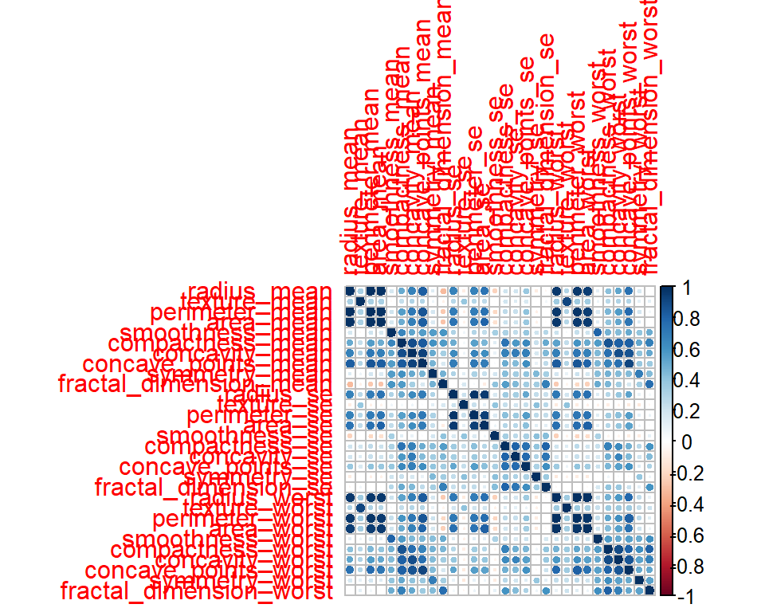

```r
library(corrplot)

cancer %>%
  select_if(is.numeric) %>%
  cor() %>%
  corrplot()
```

## 데이터 전처리

- 결측치 확인
- 범주형 변수에 label 부여

```r
cancer$diagnosis <- factor(cancer$diagnosis, label = c("Benign", "Malignant"))
cancer %>% is.na() %>% colSums()
```

```
##               diagnosis             radius_mean            texture_mean
##                       0                       0                       0
##          perimeter_mean               area_mean         smoothness_mean
##                       0                       0                       0
##        compactness_mean          concavity_mean     concave_points_mean
##                       0                       0                       0
##           symmetry_mean  fractal_dimension_mean               radius_se
##                       0                       0                       0
##              texture_se            perimeter_se                 area_se
##                       0                       0                       0
##           smoothness_se          compactness_se            concavity_se
##                       0                       0                       0
##       concave_points_se             symmetry_se    fractal_dimension_se
##                       0                       0                       0
##            radius_worst           texture_worst         perimeter_worst
##                       0                       0                       0
##              area_worst        smoothness_worst       compactness_worst
##                       0                       0                       0
##         concavity_worst    concave_points_worst          symmetry_worst
##                       0                       0                       0
## fractal_dimension_worst
##                       0
```

## 7.3 PCA

- PCA는 범주형 변수가 있으면 안되므로 numeric만 선택
- 변수 스케일에 대한 영향을 줄이기 위해 normalize 진행(center : 평균 빼기, scale : 분산으로 나누기)
- cumulative proportion을 보면 PC1:PC5 정도 선택하면 전체 분산에 84% 설명

```r
cancer_pca <- cancer %>%
  select_if(is.numeric)
pca_result <- prcomp(cancer_pca, scale = T, center = T)
summary(pca_result)
```

```
## Importance of components:
##                           PC1    PC2     PC3     PC4     PC5     PC6     PC7
## Standard deviation     3.6444 2.3857 1.67867 1.40735 1.28403 1.09880 0.82172
## Proportion of Variance 0.4427 0.1897 0.09393 0.06602 0.05496 0.04025 0.02251
## Cumulative Proportion  0.4427 0.6324 0.72636 0.79239 0.84734 0.88759 0.91010
##                            PC8    PC9    PC10   PC11    PC12    PC13    PC14
## Standard deviation     0.69037 0.6457 0.59219 0.5421 0.51104 0.49128 0.39624
## Proportion of Variance 0.01589 0.0139 0.01169 0.0098 0.00871 0.00805 0.00523
## Cumulative Proportion  0.92598 0.9399 0.95157 0.9614 0.97007 0.97812 0.98335
##                           PC15    PC16    PC17    PC18    PC19    PC20   PC21
## Standard deviation     0.30681 0.28260 0.24372 0.22939 0.22244 0.17652 0.1731
## Proportion of Variance 0.00314 0.00266 0.00198 0.00175 0.00165 0.00104 0.0010
## Cumulative Proportion  0.98649 0.98915 0.99113 0.99288 0.99453 0.99557 0.9966
##                           PC22    PC23   PC24    PC25    PC26    PC27    PC28
## Standard deviation     0.16565 0.15602 0.1344 0.12442 0.09043 0.08307 0.03987
## Proportion of Variance 0.00091 0.00081 0.0006 0.00052 0.00027 0.00023 0.00005
## Cumulative Proportion  0.99749 0.99830 0.9989 0.99942 0.99969 0.99992 0.99997
##                           PC29    PC30
## Standard deviation     0.02736 0.01153
## Proportion of Variance 0.00002 0.00000
## Cumulative Proportion  1.00000 1.00000
```

## 7.4 Screeplot

- fviz_eig로 screeplot을 그릴 수 있음

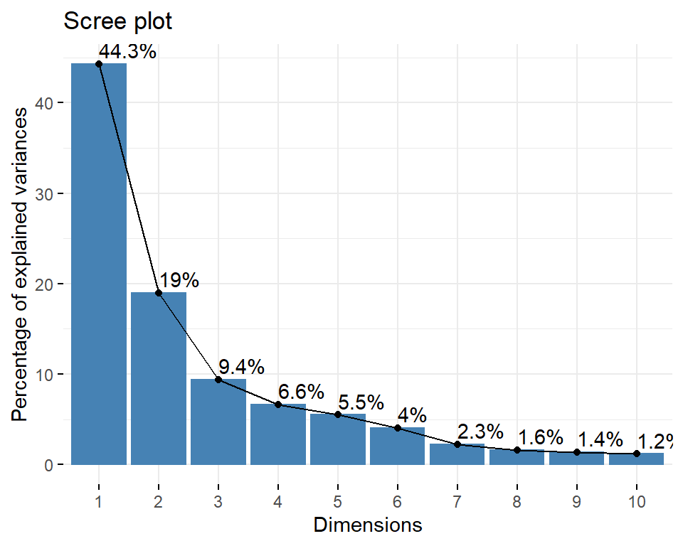

```r
fviz_eig(pca_result, addlabels = T)
```

## 7.5 bi plot

- fviz_pca_biplot()
  - col.ind : 개별 관측치에 대해 특정 변수 기준으로 색을 다르게 부여

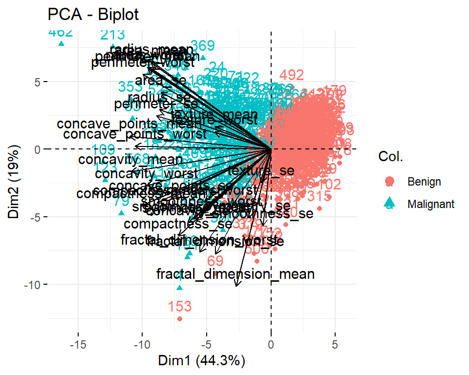

```r
fviz_pca_biplot(pca_result, col.ind = cancer$diagnosis, col = "black")
```

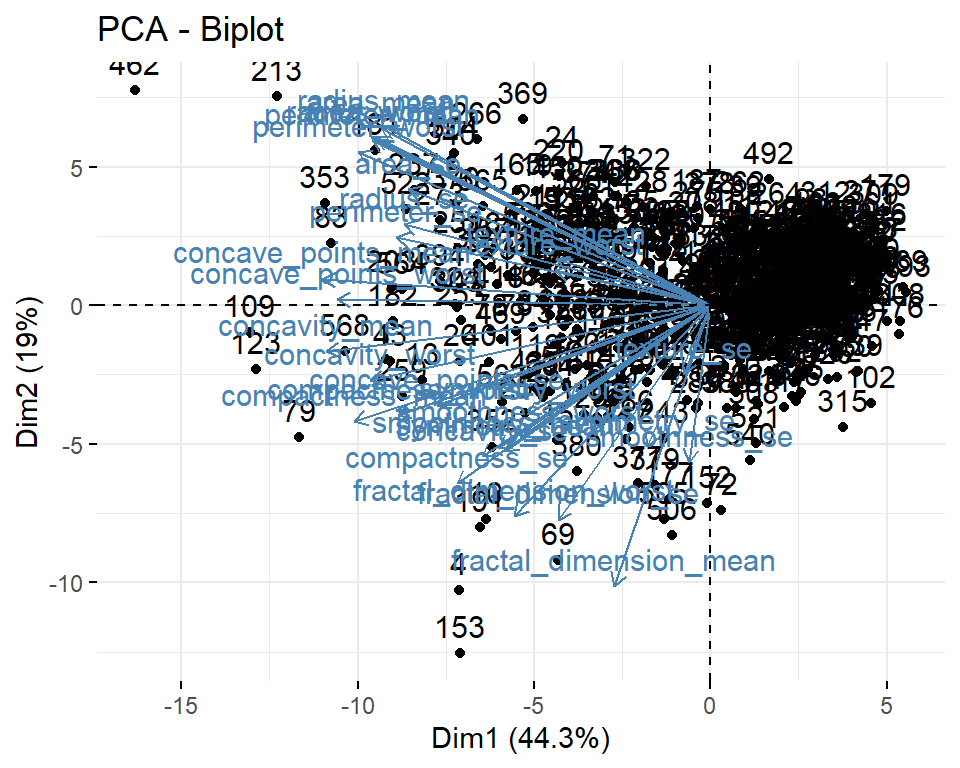

```r
fviz_pca(pca_result)
```

## 7.6 PCA한 결과로 dataframe을 만들 때

- prcomp를 할당한 결과에서 x를 추출할 수 있음

```r
pca_columns <- pca_result$x %>%
  as_tibble() %>%
  select(PC1, PC2, PC3, PC4, PC5)

df_8 <- data.frame(diagnosis = cancer$diagnosis, pca_columns)
df_8
```

```
##     diagnosis          PC1           PC2          PC3          PC4
## 1   Malignant  -9.18475521  -1.946870030 -1.122178766  3.630536408
## 2   Malignant  -2.38570263   3.764859063 -0.528827374  1.117280773
## 3   Malignant  -5.72885549   1.074228589 -0.551262540  0.911280840
## 4   Malignant  -7.11669126 -10.266555635 -3.229947535  0.152412923
## 5   Malignant  -3.93184247   1.946358977  1.388544953  2.938054169
## 6   Malignant  -2.37815462  -3.946456430 -2.932296681  0.940209586
## 7   Malignant  -2.23691506   2.687666414 -1.638471247  0.149208600
## 8   Malignant  -2.14141428  -2.338186649 -0.871180715 -0.126931171
## 9   Malignant  -3.17213315  -3.388831138 -3.117243065 -0.600768440
## 10  Malignant  -6.34616284  -7.720380945 -4.338098744 -3.372234369
## 11  Malignant   0.80970132   2.656937673 -0.488400053 -1.671096176
## 12  Malignant  -2.64876984  -0.066509405 -1.525113359  0.051216497
## 13  Malignant  -8.17783882  -2.698602007  5.725193241 -1.111278747
## 14  Malignant  -0.34182514   0.967428026  1.715661982 -0.594479872
```

[output cut: 1125 more lines]

## 7.7 recipes를 이용한 방법

- 단순히 PCA를 적용해서 모델링을 한다고 했을 때 recipes가 효율적
- 단점은 시각화 코드가 복잡해서 생략..
- recipes도 stat 패키지의 prcomp 함수를 이용하므로 결과 동일
- step_pca()
  - threshold : 주성분을 총 변동의 몇 %를 설명할 정도로 선택할 것인지
  - 위의 예시를 보면 주성분별 Cumulative Proportion이 PC4 : 0.79, PC5 : 0.84인데 treshold를 0.80으로 잡으면 PC5까지 선택됨(미만이면 초과해서 주성분이 선택됨. 주의 필요)

```r
library(recipes)

cancer %>%
  recipe(diagnosis~.) %>%
  step_normalize(all_predictors()) %>%
  step_pca(all_numeric(), threshold = 0.80) %>%
  prep() %>%
  juice() %>%
  head()
```

```
## # A tibble: 6 x 6
##   diagnosis   PC1    PC2    PC3   PC4    PC5
##   <fct>     <dbl>  <dbl>  <dbl> <dbl>  <dbl>
## 1 Malignant -9.18  -1.95 -1.12  3.63   1.19
## 2 Malignant -2.39   3.76 -0.529 1.12  -0.621
## 3 Malignant -5.73   1.07 -0.551 0.911  0.177
## 4 Malignant -7.12 -10.3  -3.23  0.152  2.96
## 5 Malignant -3.93   1.95  1.39  2.94  -0.546
## 6 Malignant -2.38  -3.95 -2.93  0.940  1.06
```

```r
df_8 %>% head() # prcomp로 적용한 결과
```

```
##   diagnosis       PC1        PC2        PC3       PC4        PC5
## 1 Malignant -9.184755  -1.946870 -1.1221788 3.6305364  1.1940595
## 2 Malignant -2.385703   3.764859 -0.5288274 1.1172808 -0.6212284
## 3 Malignant -5.728855   1.074229 -0.5512625 0.9112808  0.1769302
## 4 Malignant -7.116691 -10.266556 -3.2299475 0.1524129  2.9582754
## 5 Malignant -3.931842   1.946359  1.3885450 2.9380542 -0.5462667
## 6 Malignant -2.378155  -3.946456 -2.9322967 0.9402096  1.0551135
```

```r
library(caret)
library(rsample)


splits <- initial_split(df_8, prop = 0.7, strata = diagnosis)
train <- training(splits)
test <- testing(splits)
```

```r
set.seed(123)
control <- trainControl(method='cv',
                        number=5,
                        classProbs = T, # target이 1 or 0이 아니라 yes or no 형태여야함.
                        summaryFunction = twoClassSummary, # auc, sensitivity, specificity
                        savePredictions = T
                        )
tunegrid <- expand.grid(mtry = c(1:5))

library(tictoc)
tic()
rf_gridsearch <- train(diagnosis ~ .,
                       data = train,
                       method = 'rf',
                       trControl = control,
                       tuneGrid = tunegrid,
                       metric = "ROC",
                       verbose = F)
toc()
```

```
## 2.2 sec elapsed
```

```r
rf_gridsearch
```

```
## Random Forest
##
## 397 samples
##   5 predictor
##   2 classes: 'Benign', 'Malignant'
##
## No pre-processing
## Resampling: Cross-Validated (5 fold)
## Summary of sample sizes: 317, 318, 317, 319, 317
## Resampling results across tuning parameters:
##
##   mtry  ROC        Sens       Spec
##   1     0.9867432  0.9639184  0.9324138
##   2     0.9841078  0.9639184  0.9257471
##   3     0.9823465  0.9598367  0.9326437
##   4     0.9814384  0.9558367  0.9188506
##   5     0.9812302  0.9639184  0.9257471
##
## ROC was used to select the optimal model using the largest value.
## The final value used for the model was mtry = 1.
```

```r
pred <- predict(rf_gridsearch, newdata = test, type = "raw")

cmatrix <- caret::confusionMatrix(pred, test$diagnosis)
cmatrix
```

```
## Confusion Matrix and Statistics
##
##            Reference
## Prediction  Benign Malignant
##   Benign       106         6
##   Malignant      2        58
##
##                Accuracy : 0.9535
##                  95% CI : (0.9104, 0.9797)
##     No Information Rate : 0.6279
##     P-Value [Acc > NIR] : <2e-16
##
##                   Kappa : 0.8992
##
##  Mcnemar's Test P-Value : 0.2888
##
##             Sensitivity : 0.9815
##             Specificity : 0.9062
##          Pos Pred Value : 0.9464
##          Neg Pred Value : 0.9667
##              Prevalence : 0.6279
##          Detection Rate : 0.6163
##    Detection Prevalence : 0.6512
##       Balanced Accuracy : 0.9439
##
##        'Positive' Class : Benign
##
```